# 478_Project_

### Topic:

Data Analysis and Classification Analysis

#### Classification Target

• Target=1 means user is repetitively listening SAME event(s) triggered within a month after the very first observable listening event. • Target=0 means otherwise.

### Part-1: Dataset Preparation and Tables Aggregation:

### Part-2: Basic Data Analysis for attributes in all Tables (Train, Members, Songs)

### Part-3: Visualization

### Part-4: Dataset Cleaning

### Part-5: Dataset Spiltting (Training and Testing)

### Part-6: Classification

### Part-7: Conclusion

### Classification Accuracy Result

#### kNN classifier from sklearn:

```
Accuracy : Train= 62.35%, Test= 63% with K=19, C.V.= 61.6% with K=19
```

#### Navie_Bayes (Gaussian) classifer from sklearn:

```
Accuracy: Train = 60.71%, Test = 60.68%, C.V. = 60%
```

#### Decision Tree classifier from sklearn:

```
Accuracy: Train = 62.3%, Test = 62.2%, C.V. = 62%
```

#### Linear Discriminant Analysis classifier from sklearn:

```
Accuracy: Train = 62.07%, Test=62.09%, C.V. = 61.9%
```

#### Kmean classifier from sklearn:

```
Accuracy: 59.83%
```

#### KNN classifier:

```
Accuracy: Euclidean Distance = 59.3% with K=16, Cosine Distance = 59.3% with K=16,
            C.V.=61.7% with K=20
```

### Conclusion:

#### Classification methods were utilized throughout this project, all datasets were aggregated in order to discover relations between attributes. As we’ve seen the details of the above process, all the attributes were categorical attributes in the final dataset. Based on the above result, the Decision Tree Classifier and Linear Discriminant Analysis both come first in the six classification method. Its average accuracy is around 62% In fact, the accuracy of Linear kNN classifier which is also very closed to this is 61.7%. The most challenging part of this project is that most of the meaningful attributes are binary type of categorical attributes, so that it makes the result of KNN and KMean algorithm are NOT very accurate because it would not be able to distinguish the classes by the distance between the classes.

#### Visualization:

#### Prior to the classification process, I have performed a series data discovery work on the datasets. In order to acquire the clearer view on the data, visualization is one of the method I have utilized. By observing the details of the plots, I definitely understand deeper on the business and the relation between data attributes. The graphs not only provide me the platform to look into the data itself, they also offer me the first gateway to evaluate on the quality of predictor variables. Visualization is indispensable procedure in this project.

#### Accuracy:

#### According to the Accuracy Result, the best classifier is the Decision Tree classifier and LDA, the accuracy reaches 62% among all the other models which comprised of three categories from the original Train dataset (i.e.source_system_tab, source_screen_name, source_type etc) in binary form. Prior to finalize the result, various aggregated tables attributes combinations were tested in order to compare their accuracy. The aggregated table which has the closest accuracy result is the one with “language” attributes added to the above three attributes. However, with the consideration of model complexity and time cost to the project, I prefer to pick the models with fewer attributes (three attributes in this case).

#### Challenge:

#### There are few challenges when running on the datasets. As we understand more on the data structure of the dataset, we could realize that most of the attributes in the dataset are in binary format. In this case, I have struggled a while to decide on the type of analysis model I should implement in terms of model accuracy. For this reason, I have run trials on datasets with different combination of attributes by using the above-mentioned classification method. The other challenge is the computation time of running the model. The largest combination of dataset is consisted of 7377418 rows of Records and over 100 dummy variables (i.e. transformed categorical variables). I would believe that this is a typical challenge for most of the data analysis project. In this particular case, I first reviewed the purpose of data analysis for this business and then attempted to grep all the relevant variables for the modelling process.

# Part-1: Dataset Preparation and Tables Aggregation:

```python
#import module
import numpy as np
import pandas as pd
import urllib, time, json, sqlite3
```

### Create tables framework in sqlite and then utilize existing tables to aggregate attributes for the tables

```python
import sqlite3
from sqlite3 import OperationalError
import urllib, time, json, sqlite3
```

```python
#Create framework of the Table "Train"
train='''Create Table Train(
    customer_id VARCHAR(100),
    song_id VARCHAR(100),
    source_system_tab VARCHAR(20),
    source_screen_name VARCHAR(30),
    source_type VARCHAR(30),
    Target integer(2),

    CONSTRAINT Train_PK Primary Key (customer_id, song_id)

)
'''
#Create framework of the Table "Members"
mem='''Create Table Members(

    customer_id VARCHAR(100),
    city INTEGER(5),
    age INTEGER(5),
    gender VARCHAR(2),
    registered_via integer(10),
    reg_time VARCHAR(2),
    exp_date VARCHAR(2),

    CONSTRAINT Members_PK PRIMARY KEY (customer_id)
)
'''
#Create framework of the Table "Songs"
songs='''Create Table Songs(

    song_id VARCHAR(100),
    song_length INTEGER(20),
    genre_ids INTEGER(20),
    artist_name VARCHAR(100),
    composer VARCHAR(100),
    lyricist VARCHAR(100),
    language INTEGER(10),

    CONSTRAINT Songs_PK PRIMARY KEY (song_id)
)
'''
```

### Create the sqlite database to store the Tables created above

```python
conn=sqlite3.connect('project.db')
c=conn.cursor()

c.execute('Drop Table  if exists Train;')
c.execute(train)

c.execute('Drop Table  if exists Members;')
c.execute(mem)

c.execute('Drop Table  if exists Songs;')
c.execute(songs)

conn.commit()
conn.close()
```

### (ETL)Extract the original data from "train.csv" to a list "train_lst"

```python
start=time.time()
count=0
source=open ('./Data/Music/train.csv')
train_lst=[]

content=source.read()
lines=content.strip().split('\n')

for line in lines:
    line=line.strip().split(',')
    train_lst.append(line)
    count+=1

train_lst=train_lst[1:] #Skip the first row(attributes)
end=time.time()
end-start
```

```
37.31982207298279
```

```python
print(len(train_lst))
train_lst[0:3]
```

```
7377418
```

```
[['FGtllVqz18RPiwJj/edr2gV78zirAiY/9SmYvia+kCg=',
  'BBzumQNXUHKdEBOB7mAJuzok+IJA1c2Ryg/yzTF6tik=',
  'explore',
  'Explore',
  'online-playlist',
  '1'],
 ['Xumu+NIjS6QYVxDS4/t3SawvJ7viT9hPKXmf0RtLNx8=',
  'bhp/MpSNoqoxOIB+/l8WPqu6jldth4DIpCm3ayXnJqM=',
  'my library',
  'Local playlist more',
  'local-playlist',
  '1'],
 ['Xumu+NIjS6QYVxDS4/t3SawvJ7viT9hPKXmf0RtLNx8=',
  'JNWfrrC7zNN7BdMpsISKa4Mw+xVJYNnxXh3/Epw7QgY=',
  'my library',
  'Local playlist more',
  'local-playlist',
  '1']]
```

### (ETL)Extract the original data from "members.csv" to a list "members_lst"

```python
start=time.time()
count=0
source=open ('./Data/Music/members.csv')
members_lst=[]

content=source.read()
lines=content.strip().split('\n')

for line in lines:
    line=line.strip().split(',')
    members_lst.append(line)
    count+=1

members_lst=members_lst[1:] #Skip the first row(attributes)
end=time.time()

end-start
```

```
1.1472649574279785
```

```python
print(len(members_lst))
members_lst[0:3]
```

```
34403
```

```
[['XQxgAYj3klVKjR3oxPPXYYFp4soD4TuBghkhMTD4oTw=',
  '1',
  '0',
  '',
  '7',
  '20110820',
  '20170920'],
 ['UizsfmJb9mV54qE9hCYyU07Va97c0lCRLEQX3ae+ztM=',
  '1',
  '0',
  '',
  '7',
  '20150628',
  '20170622'],
 ['D8nEhsIOBSoE6VthTaqDX8U6lqjJ7dLdr72mOyLya2A=',
  '1',
  '0',
  '',
  '4',
  '20160411',
  '20170712']]
```

### (ETL)Extract the original data from "songs.csv" to a list "songs_lst"

```python
start=time.time()
count=0
source=open ('./Data/Music/songs.csv')
songs_lst=[]

content=source.read()
lines=content.strip().split('\n')

for line in lines:
    line=line.strip().split(',')
    songs_lst.append(line)
    count+=1

songs_lst=songs_lst[1:] #Skip the first row(attributes)
end=time.time()
end-start
```

```
10.556016206741333
```

```python
print(len(songs_lst))
print(songs_lst[0:3])
```

```
2296833
[['CXoTN1eb7AI+DntdU1vbcwGRV4SCIDxZu+YD8JP8r4E=', '247640', '465', '張信哲 (Jeff Chang)', '董貞', '何啟弘', '3.0'], ['o0kFgae9QtnYgRkVPqLJwa05zIhRlUjfF7O1tDw0ZDU=', '197328', '444', 'BLACKPINK', 'TEDDY|  FUTURE BOUNCE|  Bekuh BOOM', 'TEDDY', '31.0'], ['DwVvVurfpuz+XPuFvucclVQEyPqcpUkHR0ne1RQzPs0=', '231781'…
```

### (ETL) Extract the data from the list "members_lst" and Load to the table into database

```python
#Insert the train table data into sqlite for future data aggregation
start=time.time()
conn=sqlite3.connect('project.db')
c=conn.cursor()
c.executemany('INSERT OR IGNORE INTO Members VALUES (?,?,?,?,?,?,?);', members_lst)
conn.commit()
end=time.time()
end-start
```

```
0.5544729232788086
```

### (ETL) Extract the data from the list "songs_lst" and Load to the table into database

```python
#Insert the songs table data into sqlite for future data aggregation
count=0
for line in songs_lst:
    try:
        c.execute('INSERT OR IGNORE INTO Songs VALUES (?,?,?,?,?,?,?);', line)
        count+=1
    except:
        print(count)
conn.commit()
```

```
605199
```

```python
####(ETL) Extract the data from the list "train_lst" and Load to the table into database
```

```python
#Insert the train_sys table data into sqlite for future data aggregation

c.executemany('INSERT OR IGNORE INTO Train VALUES (?,?,?,?,?,?);', train_lst)
conn.commit()
```

### (ETL)Aggregate the tables from Train, Songs, Members and Load into the CSV files for the analysis.

```python
start=time.time()
#Query for all the attributes from all the Tables corresponding to the customer_id an Songs_id
query1='''select T.customer_id, T.Song_id, T.source_system_tab,T.source_screen_name, T.source_type,
M.city, M.age, M.gender,M.registered_via, M.reg_time, exp_date,
s.genre_ids,s.song_length,s.language,s.artist_name,s.composer, s.lyricist, T.target
from Train T
left Join Members M on T.customer_id=M.customer_id
Left join songs s on s.song_id=t.song_id;
'''
#Query for all the attributes from the Train Table
que_train='''Select * from Train'''

#Query for all the attributes from the Songs Table
que_songs='''select t.Song_id,
s.genre_ids,s.song_length,s.language,s.artist_name,s.composer, s.lyricist, T.target
from Songs t
Left Join songs s on t.song_id=s.song_id'''

#Query all the attributes from the members Table
que_members='''Select t.customer_id,
M.city, M.age, M.gender,M.registered_via, M.reg_time, exp_date, t.target
from Train t, Members m,
Left Join Members m on m.customer_id=t.customer_id'''

#Add the Gender, Language, genre_ids to the Train Tables
query2='''
Select
t.customer_id,t.Song_id,t.target,T.source_system_tab,T.source_screen_name, T.source_type,
M.gender,
s.language,s.genre_ids,s.artist_name
from Train t,songs s, Members m
on m.customer_id=t.customer_id and t.song_id=s.song_id'''

#Load the above queries to the CSV files for future use.
#pd.read_sql_query(que_songs, conn).to_csv('que_songs.csv', index=True)
pd.read_sql_query(query2, conn).to_csv('query2.csv', index=True)
end=time.time()
print("Time taken is ", end-start)
```

```
Time taken is  353.4293489456177
```

### Read the CSV file which was prepared from the above Query

```python
import pandas as pd
import numpy as np
original_tbl=pd.read_csv('''query1.csv''', na_values=["?"])
#train_tbl=pd.read_csv('''que_train.csv''', na_values=["?"])
#songs_tbl=pd.read_csv('''que_songs.csv''', na_values=["?"])
#members_tbl=pd.read_csv('''que_members.csv''', na_values=["?"])
#train2_tbl=pd.read_csv('''query2.csv''', na_values=["?"])
```

```python
print(original_tbl.shape)
original_tbl.head(3)
```

```
(7377418, 19)
```

|  | Unnamed: 0 | customer_id | song_id | source_system_tab | source_screen_name | source_type | city | age | gender | registered_via | reg_time | exp_date | genre_ids | song_length | language | artist_name | composer | lyricist | Target |
| --- | --- | --- | --- | --- | --- | --- | --- | --- | --- | --- | --- | --- | --- | --- | --- | --- | --- | --- | --- |
| 0 | 0 | FGtllVqz18RPiwJj/edr2gV78zirAiY/9SmYvia+kCg= | BBzumQNXUHKdEBOB7mAJuzok+IJA1c2Ryg/yzTF6tik= | explore | Explore | online-playlist | 1 | 0 | NaN | 7 | 20120102 | 20171005 | 359 | 206471.0 | 52.0 | Bastille | Dan Smith\| Mark Crew | NaN | 1 |
| 1 | 1 | Xumu+NIjS6QYVxDS4/t3SawvJ7viT9hPKXmf0RtLNx8= | bhp/MpSNoqoxOIB+/l8WPqu6jldth4DIpCm3ayXnJqM= | my library | Local playlist more | local-playlist | 13 | 24 | female | 9 | 20110525 | 20170911 | 1259 | 284584.0 | 52.0 | Various Artists | NaN | NaN | 1 |
| 2 | 2 | Xumu+NIjS6QYVxDS4/t3SawvJ7viT9hPKXmf0RtLNx8= | JNWfrrC7zNN7BdMpsISKa4Mw+xVJYNnxXh3/Epw7QgY= | my library | Local playlist more | local-playlist | 13 | 24 | female | 9 | 20110525 | 20170911 | 1259 | 225396.0 | 52.0 | Nas | N. Jones、W. Adams、J. Lordan、D. Ingle | NaN | 1 |

# Part-2: Basic Data Analysis for attributes in all Tables (Train, Members, Songs)

```python
#Copy the original dataset to aother variable to avoid any changes to the original dataset (ALL Attriutes)
music_tbl=original_tbl.copy()
#Drop the original row ID column
music_tbl.drop('Unnamed: 0',axis=1,inplace=True)
#Statistics of all the attributes (Numeric and Categorical)
music_tbl.describe(include='all')
```

|  | customer_id | song_id | source_system_tab | source_screen_name | source_type | city | age | gender | registered_via | reg_time | exp_date | genre_ids | song_length | language | artist_name | composer | lyricist | Target |
| --- | --- | --- | --- | --- | --- | --- | --- | --- | --- | --- | --- | --- | --- | --- | --- | --- | --- | --- |
| count | 7377418 | 7377418 | 7359047 | 6962614 | 7355879 | 7.377418e+06 | 7.377418e+06 | 4415939 | 7.377418e+06 | 7.377418e+06 | 7.377418e+06 | 7259039 | 7.377380e+06 | 7.377380e+06 | 7377380 | 5701740 | 4198611 | 7.377418e+06 |
| unique | 30755 | 359966 | 9 | 20 | 12 | NaN | NaN | 2 | NaN | NaN | NaN | 572 | NaN | NaN | 40586 | 76070 | 33893 | NaN |
| top | MXIMDXO0j3UpaT7FvOSGW6Y5zfhlh+xYjTqGoUdMzEE= | reXuGcEWDDCnL0K3Th//3DFG4S1ACSpJMzA+CFipo1g= | my library | Local playlist more | local-library | NaN | NaN | male | NaN | NaN | NaN | 465 | NaN | NaN | Various Artists | 周杰倫 | 阿信 | NaN |
| freq | 5819 | 13973 | 3684730 | 3228202 | 2261399 | NaN | NaN | 2297623 | NaN | NaN | NaN | 3717730 | NaN | NaN | 303617 | 201910 | 151301 | NaN |
| mean | NaN | NaN | NaN | NaN | NaN | 7.511399e+00 | 1.753927e+01 | NaN | 6.794068e+00 | 2.012810e+07 | 2.017157e+07 | NaN | 2.451213e+05 | 1.860954e+01 | NaN | NaN | NaN | 5.035171e-01 |
| std | NaN | NaN | NaN | NaN | NaN | 6.641625e+00 | 2.155447e+01 | NaN | 2.275774e+00 | 3.017281e+04 | 3.869831e+03 | NaN | 6.734489e+04 | 2.117690e+01 | NaN | NaN | NaN | 4.999877e-01 |
| min | NaN | NaN | NaN | NaN | NaN | 1.000000e+00 | -4.300000e+01 | NaN | 3.000000e+00 | 2.004033e+07 | 1.970010e+07 | NaN | 1.393000e+03 | -1.000000e+00 | NaN | NaN | NaN | 0.000000e+00 |
| 25% | NaN | NaN | NaN | NaN | NaN | 1.000000e+00 | 0.000000e+00 | NaN | 4.000000e+00 | 2.011070e+07 | 2.017091e+07 | NaN | 2.147260e+05 | 3.000000e+00 | NaN | NaN | NaN | 0.000000e+00 |
| 50% | NaN | NaN | NaN | NaN | NaN | 5.000000e+00 | 2.100000e+01 | NaN | 7.000000e+00 | 2.013102e+07 | 2.017093e+07 | NaN | 2.418120e+05 | 3.000000e+00 | NaN | NaN | NaN | 1.000000e+00 |
| 75% | NaN | NaN | NaN | NaN | NaN | 1.300000e+01 | 2.900000e+01 | NaN | 9.000000e+00 | 2.015102e+07 | 2.017101e+07 | NaN | 2.721600e+05 | 5.200000e+01 | NaN | NaN | NaN | 1.000000e+00 |
| max | NaN | NaN | NaN | NaN | NaN | 2.200000e+01 | 1.051000e+03 | NaN | 1.300000e+01 | 2.017013e+07 | 2.020102e+07 | NaN | 1.085171e+07 | 5.900000e+01 | NaN | NaN | NaN | 1.000000e+00 |

#### As we can see, there are Numeric and Categorical Attributes in the datasets, further data exploration below to decide which attributes would be include in the Classification part.

```python
#Remove age values Below ZERO and Above 144 (Be Real)
#set(music_tbl['age'])
music_tbl.drop(music_tbl[music_tbl['age']<=0].index,axis=0,inplace=True)
music_tbl.drop(music_tbl[music_tbl['age']>144].index,axis=0,inplace=True)
```

```python
#Categorized the 'Age' attributes values to 4 category
music_tbl['age']=pd.qcut(music_tbl.age,[0, .1, .21,0.31, .45, 1.0],['0-15','16-30','31-45','46-65','>65'])

#Categorized the "Song_Length" attributes values to 4 category
music_tbl['song_length']=pd.qcut(music_tbl.song_length,[0, .25, .5, .75, 1.],['short','med_short','mid_long','long'])
```

# Part-3: Visualization

### Check out the distribution of different attributes in the dataset

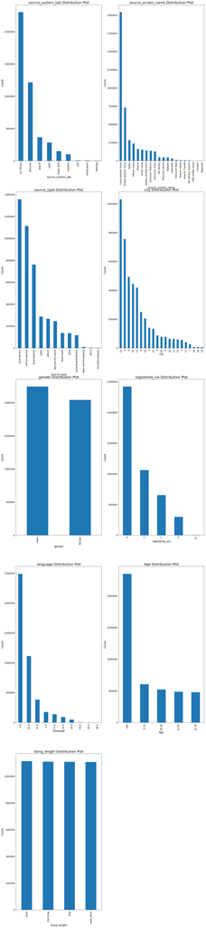

```python
#Using matplotlib module for graph plotting
import matplotlib.pyplot as plt
%matplotlib inline
fig = plt.figure(figsize=(20, 180))
# Create an Axes object.

ax1 = fig.add_subplot(9,2,1) # one row, two column, first plot
# Plot the data.
music_tbl['source_system_tab'].value_counts().plot(kind='bar')
ax1.set_title("source_system_tab Distribution Plot", size=20)
ax1.set_xlabel("source_system_tab", size=15)
ax1.set_ylabel("Count", size=15)
ax1.tick_params(axis='x', labelsize=14)
ax1.tick_params(axis='y', labelsize=14)

ax2 = fig.add_subplot(9,2,2)
music_tbl['source_screen_name'].value_counts().plot(kind='bar')
ax2.set_title("source_screen_name Distribution Plot", size=20)
ax2.set_xlabel("source_screen_name", size=15)
ax2.set_ylabel("Count", size=15)
ax2.tick_params(axis='x', labelsize=14)
ax2.tick_params(axis='y', labelsize=14)

ax3 = fig.add_subplot(9,2,3)
music_tbl['source_type'].value_counts().plot(kind='bar')
ax3.set_title("source_type Distribution Plot", size=20)
ax3.set_xlabel("source_type", size=15)
ax3.set_ylabel("Count", size=15)
ax3.tick_params(axis='x', labelsize=14)
ax3.tick_params(axis='y', labelsize=14)


ax4 = fig.add_subplot(9,2,4)
music_tbl['city'].value_counts().plot(kind='bar')
ax4.set_title("city Distribution Plot", size=20)
ax4.set_xlabel("city", size=15)
ax4.set_ylabel("Count", size=15)
ax4.tick_params(axis='x', labelsize=14)
ax4.tick_params(axis='y', labelsize=14)

ax5 = fig.add_subplot(9,2,5)
music_tbl['gender'].value_counts().plot(kind='bar')
ax5.set_title("gender Distribution Plot", size=20)
ax5.set_xlabel("gender", size=15)
ax5.set_ylabel("Count", size=15)
ax5.tick_params(axis='x', labelsize=14)
ax5.tick_params(axis='y', labelsize=14)

ax6 = fig.add_subplot(9,2,6)
music_tbl['registered_via'].value_counts().plot(kind='bar')
ax6.set_title("registered_via Distribution Plot", size=20)
ax6.set_xlabel("registered_via", size=15)
ax6.set_ylabel("Count", size=15)
ax6.tick_params(axis='x', labelsize=14)
ax6.tick_params(axis='y', labelsize=14)

ax7 = fig.add_subplot(9,2,7)
music_tbl['language'].value_counts().plot(kind='bar')
ax7.set_title("language Distribution Plot", size=20)
ax7.set_xlabel("language", size=15)
ax7.set_ylabel("Count", size=15)
ax7.tick_params(axis='x', labelsize=14)
ax7.tick_params(axis='y', labelsize=14)

ax8 = fig.add_subplot(9,2,8)
music_tbl['age'].value_counts().plot(kind='bar')
ax8.set_title("Age Distribution Plot", size=20)
ax8.set_xlabel("Age", size=15)
ax8.set_ylabel("Count", size=15)
ax8.tick_params(axis='x', labelsize=14)
ax8.tick_params(axis='y', labelsize=14)

ax9 = fig.add_subplot(9,2,9)
music_tbl['song_length'].value_counts().plot(kind='bar')
ax9.set_title("Song_length Distribution Plot", size=20)
ax9.set_xlabel("Song Length", size=15)
ax9.set_ylabel("Count", size=15)
ax9.tick_params(axis='x', labelsize=14)
ax9.tick_params(axis='y', labelsize=14)
```

### Brief Description on graph above

#### source_system_tab:KKBox defines this is the tab that shows the event was triggered and this function is used to categorize the KKBox App function - According to the above plot, we could observe that "my library" and "discover" are majorly dominated the count in this attribute. In other words, most of the event is triggered in the "my library" mode and the second most of event is triggered by "discover" mode. By looking at this stat, we can rougly guess if songs are store in "my library" or found from "discover", there is a quite high of chance the songs would be picked up by users.

#### source_screen_name: KKBox defines this is the tab where the screen is being seen when the event was trigger - "Local playlist more" is apparently the layout users stay on when the event is triggered. Its count is roughly 3x times more than the layout in the second place which is "online playlist more". As we've seen, the result makes sense to me because users are mostly like to download songs to their playlist to listen (Especially for their favorite ones). Other than that, I guess everyone knows that online musice is very popular now, users could find various channels online to get sonngs.

#### "source_type": KKBox defines this is the entry-point where users first get the songs loading - Three major type of sources which are "local-library", "online-playlist" and "local-playlist" we could observe in the plot. This outcome is very consistent to the above "source_screen_name" and "source_system_tab" plots. Local library source and onlne playlist are ranked top on the songs type. These could imply that users are mostly start the event (i.e. listen the songs) in these 2 channels rather than other sources channels (e.g. radio etc.).

#### City: KKBox did not reveal the real name of the city on the dataset. For this reason, we could only look at the city code in the plot - It indicates city 13 have the most of users which are almost twice more users than other cities. The second city with great count of users is City 5. I would guess that KKBox would have get big part of business if they could advertise properly in these 2 cities. On the contrary, it is a good idea to increase their effort to spread their brand in the rest of cities which have small amount of users in order to grow their business.

#### Gender: This plot is quite simple that the count of Male users is slightly more then Female. I would say that this result is not a very relevant to read any particular habit out of users.

#### "Song_Length" - The attributes were categorized into 4 categories. The plot shows that the count of songs are evenly distributed, so that I would not think this would be a good predictor to the user song-listen habit.

#### Genre_ids Distribution Plot

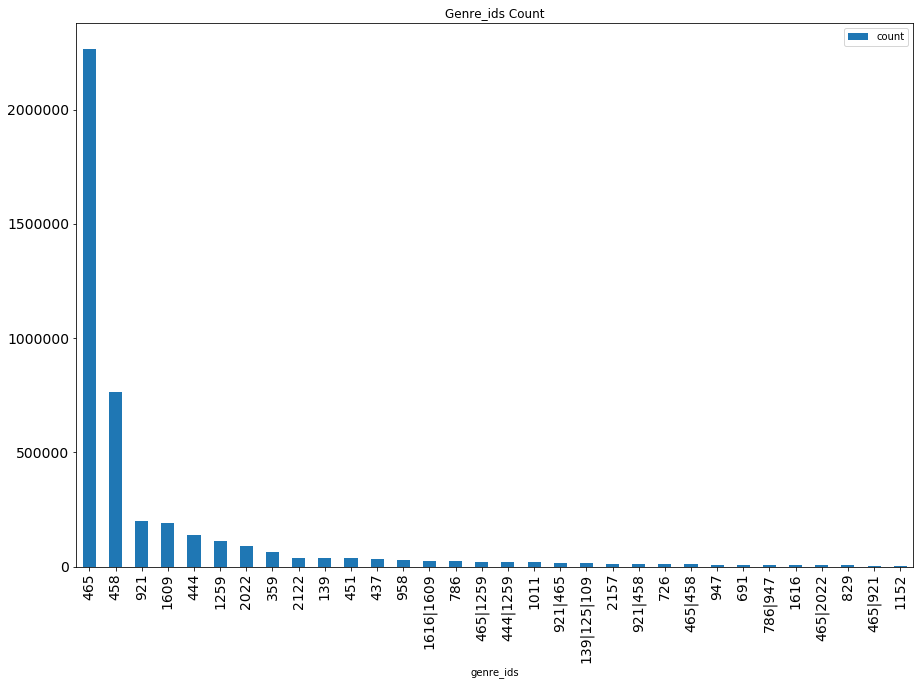

```python
i_lst=[]
cnt_lst=[]
val_lst=[]
for i ,(val, cnt) in enumerate(music_tbl['genre_ids'].value_counts().iteritems()):
    i_lst.append(i)
    cnt_lst.append(cnt)
    val_lst.append(val)
i_lst=np.array(i_lst)
cnt_lst=np.array(cnt_lst)
val_lst=np.array(val_lst)

idx=np.argsort(cnt_lst)[::-1]
type(val_lst)
type(cnt_lst)
aa=pd.DataFrame({'count':cnt_lst[idx].tolist(),'genre_ids':val_lst[idx].tolist()})

#Display Genre_ids which is count is higher than 5000.
aa[aa['count']>5000].set_index('genre_ids').plot.bar(figsize=(15,10)
                                                     ,title='Genre_ids Count'
                                                     , fontsize=14)
plt.xticks(rotation=90)

plt.show()
```

#### "Genre_ids": This attribute tells us which Genre the songs fall into. The dataset includes over 30 types of genre_ids. So that I have filtered out low counts genres which means the above plot only shows those genres appears in the dataset more than 5000 times or more. Similar to other attributes, KKBox did not reveal the real name of the genres. As we seen above, some of the genres code represent 2 types of genres combined. The most popular genre which is 465 is about 3 fold of the second place genre (i.e.458). Since the result is so skewed, so that I decided to only looked into the genre_ids 465 and 458 ONLY in the classification analysis.

#### Genre_ids vs Target Group plot

```python
music_tbl2 = music_tbl[(music_tbl['genre_ids']=="465") | (music_tbl['genre_ids']=="458")]
music_tbl2.shape
```

```
(4978940, 18)
```

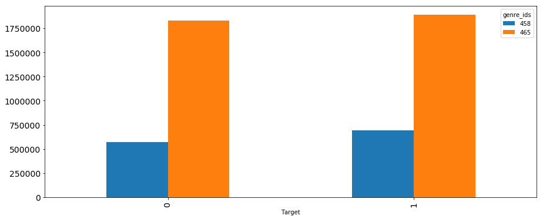

| genre_ids Target | 458 | 465 |
| --- | --- | --- |
| 0 | 569513 | 1829513 |
| 1 | 691697 | 1888217 |

```python
np.set_printoptions(precision=2, linewidth=200, suppress=False)
cro_tar_genre=pd.crosstab(music_tbl2['Target'],music_tbl2['genre_ids'])
cro_tar_genre.plot.bar(figsize=(15,6),fontsize=14)
plt.show()
cro_tar_genre
```

#### The above is the plot shows the genre_ids react in the Target group. As we seen, there are NOT much differeniation between the Target group. Genre 458, 465 are very closed to each other. So that the genre_ids would not be added to the following classification analysis.

### "artist name" attribute Distribution

```
        artist_name   count
0   Various Artists  303617
1    周杰倫 (Jay Chou)  186776
2      五月天 (Mayday)  182088
3      林俊傑 (JJ Lin)  115325
4        田馥甄 (Hebe)  104946
5        aMEI (張惠妹)   82799
6  陳奕迅 (Eason Chan)   76035
7               玖壹壹   70445
8         G.E.M.鄧紫棋   67297
9           BIGBANG   61927
```

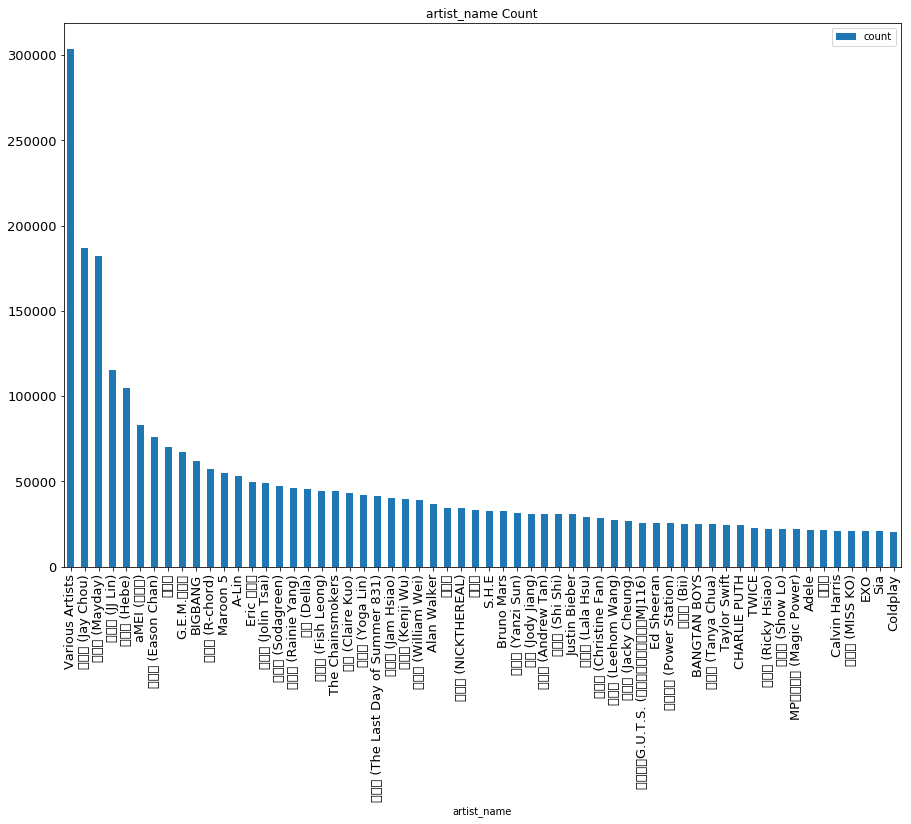

```python
i_lst=[]
cnt_lst=[]
val_lst=[]
for i ,(val, cnt) in enumerate(music_tbl['artist_name'].value_counts().iteritems()):
    i_lst.append(i)
    cnt_lst.append(cnt)
    val_lst.append(val)
i_lst=np.array(i_lst)
cnt_lst=np.array(cnt_lst)
val_lst=np.array(val_lst)

idx=np.argsort(cnt_lst)[::-1]
type(val_lst)
type(cnt_lst)
aa=pd.DataFrame({'count':cnt_lst[idx].tolist(),'artist_name':val_lst[idx].tolist()})

print(aa[0:10])

#Display Genre_ids which is count is higher than 10000.
aa[aa['count']>20000].set_index('artist_name').plot.bar(figsize=(15,10)
                                                        ,title='artist_name Count'
                                                        ,fontsize=13)
plt.xticks(rotation=90)
plt.show()
```

#### Artist_name vs Target Group plot

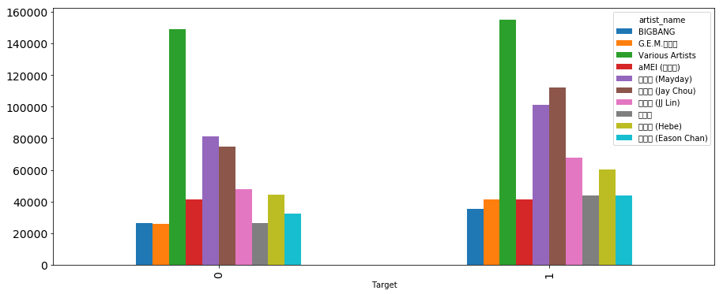

| artist_name Target | BIGBANG | G.E.M.鄧紫棋 | Various Artists | aMEI (張惠妹) | 五月天 (Mayday) | 周杰倫 (Jay Chou) | 林俊傑 (JJ Lin) | 玖壹壹 | 田馥甄 (Hebe) | 陳奕迅 (Eason Chan) |
| --- | --- | --- | --- | --- | --- | --- | --- | --- | --- | --- |
| 0 | 26610 | 25873 | 148818 | 41301 | 81061 | 74549 | 47704 | 26481 | 44465 | 32140 |
| 1 | 35317 | 41424 | 154799 | 41498 | 101027 | 112227 | 67621 | 43964 | 60481 | 43895 |

```python
music_tbl3 = music_tbl[(music_tbl['artist_name']=="Various Artists")
          | (music_tbl['artist_name']=="周杰倫 (Jay Chou)")
          | (music_tbl['artist_name']=="五月天 (Mayday)")
          | (music_tbl['artist_name']=="林俊傑 (JJ Lin)")
          | (music_tbl['artist_name']=="五月天 (Mayday)")
          | (music_tbl['artist_name']=="田馥甄 (Hebe)")
          | (music_tbl['artist_name']=="aMEI (張惠妹)")
          | (music_tbl['artist_name']=="陳奕迅 (Eason Chan)")
          | (music_tbl['artist_name']=="玖壹壹" )
          | (music_tbl['artist_name']=="G.E.M.鄧紫棋")
          | (music_tbl['artist_name']=="BIGBANG")
         ]

np.set_printoptions(precision=2, linewidth=200, suppress=False)
cro_tar_artist=pd.crosstab(music_tbl3['Target'],music_tbl3['artist_name'])
cro_tar_artist.plot.bar(figsize=(15,6),fontsize=14)
plt.show()
cro_tar_artist
```

### Target vs source_system_tab Plot

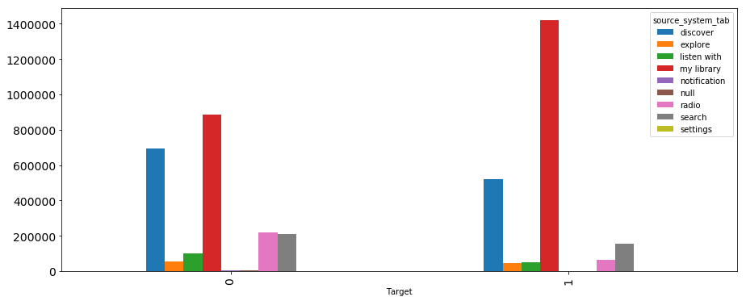

| source_system_tab Target | discover | explore | listen with | my library | notification | null | radio | search | settings |
| --- | --- | --- | --- | --- | --- | --- | --- | --- | --- |
| 0 | 694336 | 55173 | 98083 | 884619 | 2467 | 2654 | 217752 | 210600 | 708 |
| 1 | 520595 | 44875 | 49906 | 1418450 | 1470 | 1866 | 64868 | 153338 | 1039 |

```python
np.set_printoptions(precision=2, linewidth=200, suppress=False)
cro_tar_sst=pd.crosstab(music_tbl['Target'],music_tbl['source_system_tab'])
cro_tar_sst.plot.bar(figsize=(15,6),fontsize=14)
plt.show()
cro_tar_sst
```

### Target vs Source_type plot

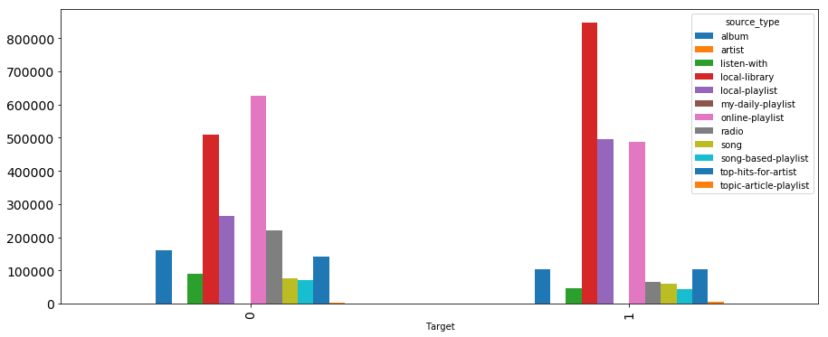

| source_type Target | album | artist | listen-with | local-library | local-playlist | my-daily-playlist | online-playlist | radio | song | song-based-playlist | top-hits-for-artist | topic-article-playlist |
| --- | --- | --- | --- | --- | --- | --- | --- | --- | --- | --- | --- | --- |
| 0 | 161283 | 710 | 90806 | 508902 | 263848 | 98 | 625402 | 221655 | 75096 | 71902 | 142273 | 3712 |
| 1 | 103986 | 1007 | 45219 | 846266 | 496251 | 68 | 487468 | 64709 | 59149 | 44746 | 102706 | 4110 |

```python
cro_tar_st=pd.crosstab(music_tbl['Target'],music_tbl['source_type'])
cro_tar_st.plot.bar(figsize=(15,6),fontsize=14)
plt.show()
cro_tar_st
```

#### Based on the above plot, we can obersve that the source_type could be differentiate between Target group (0,1). Especially the few higher ranked categories (local-library, local playlist etc). For this reason, "source_type" will be added attribute to the classification analysis.

### Target vs city

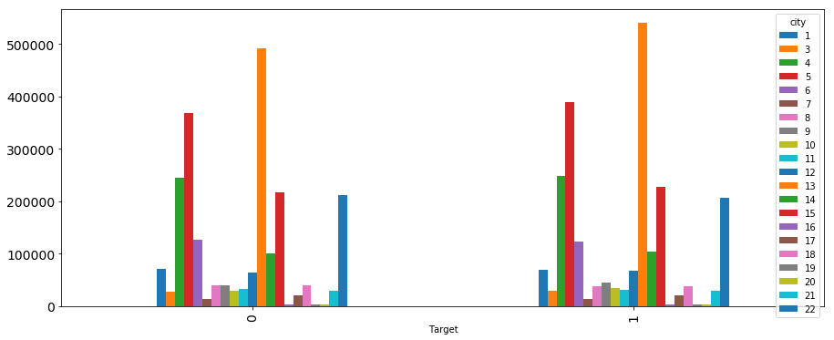

| city Target | 1 | 3 | 4 | 5 | 6 | 7 | 8 | 9 | 10 | 11 | ... | 13 | 14 | 15 | 16 | 17 | 18 | 19 | 20 | 21 | 22 |
| --- | --- | --- | --- | --- | --- | --- | --- | --- | --- | --- | --- | --- | --- | --- | --- | --- | --- | --- | --- | --- | --- |
| 0 | 71144 | 27052 | 243958 | 367432 | 125832 | 13083 | 38962 | 40080 | 29357 | 32411 | ... | 490631 | 99770 | 216789 | 3539 | 19973 | 39956 | 3706 | 2544 | 28905 | 212001 |
| 1 | 68979 | 28661 | 248840 | 388104 | 123751 | 13146 | 38228 | 45713 | 34248 | 30725 | ... | 539564 | 104366 | 227238 | 3298 | 20909 | 37386 | 2823 | 3351 | 29802 | 205892 |

2 rows × 21 columns

```python
cro_tar_city=pd.crosstab(music_tbl['Target'],music_tbl['city'])
cro_tar_city.plot.bar(figsize=(15,6),fontsize=14)
plt.show()
cro_tar_city
```

### Target vs Gender

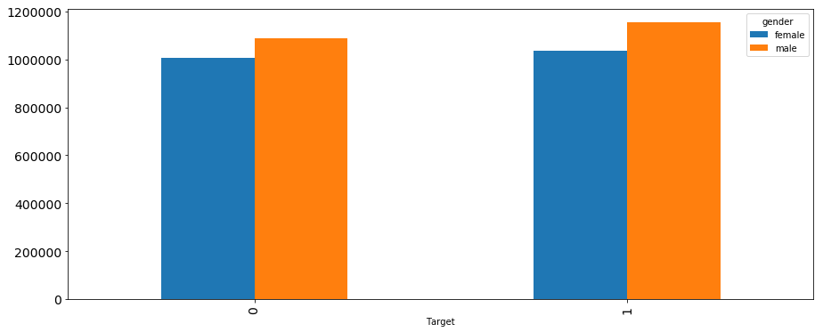

| gender Target | female | male |
| --- | --- | --- |
| 0 | 1007449 | 1089721 |
| 1 | 1035957 | 1153738 |

```python
cro_tar_gender=pd.crosstab(music_tbl['Target'],music_tbl['gender'])
cro_tar_gender.plot.bar(figsize=(15,6),fontsize=14)
plt.show()
cro_tar_gender
```

#### The above plot indicates tthat the counts of gender group is very similar between Target group 0 and 1. So that gender group might not be a good indicator to be added to the classification analysis.

### Target vs registered_via

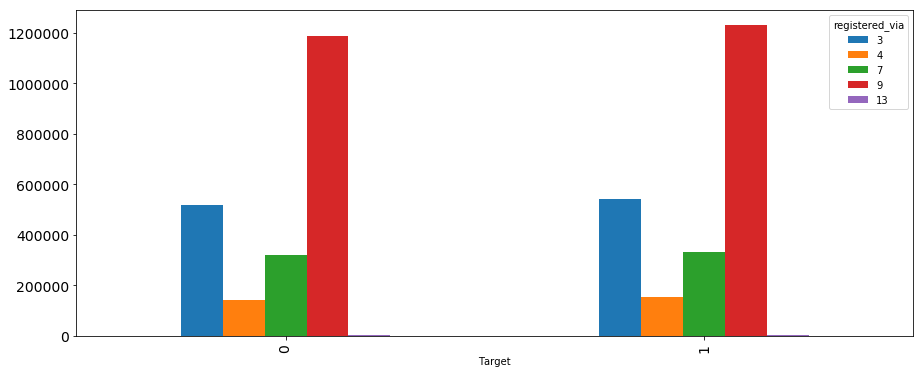

| registered_via Target | 3 | 4 | 7 | 9 | 13 |
| --- | --- | --- | --- | --- | --- |
| 0 | 518301 | 142592 | 319658 | 1189406 | 1870 |
| 1 | 543131 | 154674 | 333220 | 1230124 | 2144 |

```python
cro_tar_rv=pd.crosstab(music_tbl['Target'],music_tbl['registered_via'])
cro_tar_rv.plot.bar(figsize=(15,6),fontsize=14)
plt.show()
cro_tar_rv
```

### As we see above, the "register_via" attribute have similar counts in both Target group 0 and 1. For this reason, there is a high chance that registered_via would not be a good predictor to classify Target group. In this case, "registered_via" attribute will not be added to the classification analysis.

### Target vs song_length

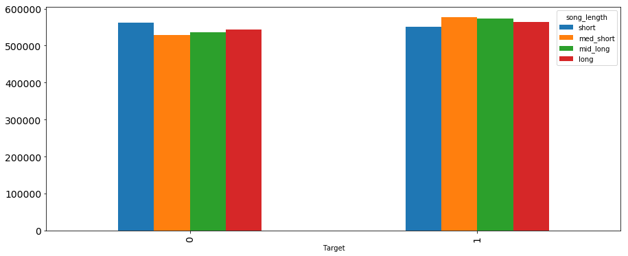

| song_length Target | short | med_short | mid_long | long |
| --- | --- | --- | --- | --- |
| 0 | 561897 | 529579 | 536734 | 543608 |
| 1 | 551183 | 576363 | 572535 | 563196 |

```python
cro_tar_sl=pd.crosstab(music_tbl['Target'],music_tbl['song_length'])
cro_tar_sl.plot.bar(figsize=(15,6),fontsize=14)
plt.show()
cro_tar_sl
```

#### The above song_length attribute was categorized into 4 groups in the previous steps. As we observe the above plot, we could find that the song_length attribute does not have much difference between Target group 0 and group 1. This implies that song_length would not be a good predictor in the classification analysis. So that "song_length" attribute would not be added to the classification analysis.

### Target vs Language

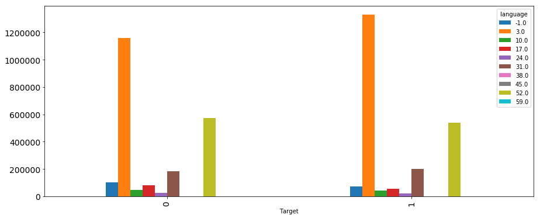

| language Target | -1.0 | 3.0 | 10.0 | 17.0 | 24.0 | 31.0 | 38.0 | 45.0 | 52.0 | 59.0 |
| --- | --- | --- | --- | --- | --- | --- | --- | --- | --- | --- |
| 0 | 101484 | 1159752 | 48082 | 81746 | 25327 | 181822 | 61 | 668 | 571757 | 1119 |
| 1 | 74164 | 1328398 | 41155 | 56694 | 21890 | 199638 | 53 | 422 | 539676 | 1187 |

```python
cro_tar_language=pd.crosstab(music_tbl['Target'],music_tbl['language'])
cro_tar_language.plot.bar(figsize=(15,6),fontsize=14)
plt.show()
cro_tar_language
```

#### For this particular analysis, we focus on the dataset which built from Asian countries. Language of songs certainly a curial factor we should consider favor to the users. As we seen above the language 3.0 and 52.0 are basically the main trends of language of songs in KKBox. So that I would only extract these two categories' songs for the classification purpose.

```python
np.set_printoptions(precision=2, linewidth=120, suppress=True)

music_tbl.groupby('Target').describe()
```

[output not shown]

# Part-4:Dataset Cleaning

```python
import pandas as pd
import numpy as np
#original_tbl=pd.read_csv('''query1.csv''', na_values=["?"])
#train_tbl=pd.read_csv('''que_train.csv''', na_values=["?"])
#songs_tbl=pd.read_csv('''que_songs.csv''', na_values=["?"])
#members_tbl=pd.read_csv('''que_members.csv''', na_values=["?"])
train2_tbl=pd.read_csv('''query2.csv''', na_values=["?"])
```

#### Based on the previous trail testing, The final dataset I used for final analysis is train2_tbl

```python
#Permutate the table order for the following analysis
train2_tbl = train2_tbl.reindex(np.random.permutation(train2_tbl.index))
```

```python
#Copy the original dataset to aother variable to avoid any changes to the original dataset
tbl=train2_tbl.copy()
print(tbl.shape)
tbl.head(3)
```

```
(7377380, 11)
```

|  | Unnamed: 0 | customer_id | song_id | Target | source_system_tab | source_screen_name | source_type | gender | language | genre_ids | artist_name |
| --- | --- | --- | --- | --- | --- | --- | --- | --- | --- | --- | --- |
| 1697228 | 1697228 | 9Lvvq4T/Mt8NFO56dGeSf6uX44q511IC3kDIJ/gZKQs= | NEDRivVto5J+/DdgjP7jvkVWQGgwMOm2csnLetQ3acw= | 1 | discover | Discover Genre | online-playlist | NaN | 52 | 359 | Coldplay |
| 1847372 | 1847372 | dNej6QQyFUnd6dFNKL52m0UweuUGKCMVVodv6FaN0Cc= | LB+zaSFBNcjSdXOw6M8BWfufaGq5MExgI+7H/LIF4k4= | 0 | my library | Local playlist more | local-library | NaN | 31 | 444 | SANDEUL |
| 2220879 | 2220879 | g+theVUcEcr98NxKETtsZvdyD2OWVgqd9gN/ulB0rG0= | ekxvmPlhCYTjbQrQEr9QwkI1ol5nHefMXTN98FSYdZQ= | 1 | my library | Local playlist more | local-library | male | 31 | 444 | TWICE |

```python
#Drop all the null values
tbl.drop(tbl[tbl['source_system_tab'].isnull()].index,axis=0,inplace=True)
tbl.drop(tbl[tbl['source_screen_name'].isnull()].index,axis=0,inplace=True)
tbl.drop(tbl[tbl['source_type'].isnull()].index,axis=0,inplace=True)

#tbl.drop(tbl[tbl['Target'].isnull()].index,axis=0,inplace=True)
tbl.drop(tbl[tbl['gender'].isnull()].index,axis=0,inplace=True)
tbl.drop(tbl[tbl['language'].isnull()].index,axis=0,inplace=True)
tbl.drop(tbl[tbl['genre_ids'].isnull()].index,axis=0,inplace=True)

#We focus on the langauge 52 and 3, so we drop all the rest of language
tbl.drop(tbl[tbl['language']== -1.0].index, axis=0,inplace= True)
tbl.drop(tbl[tbl['language']== 10.0].index, axis=0,inplace= True)
tbl.drop(tbl[tbl['language']== 17.0].index, axis=0,inplace= True)
tbl.drop(tbl[tbl['language']== 24.0].index, axis=0,inplace= True)
tbl.drop(tbl[tbl['language']== 31.0].index, axis=0,inplace= True)
tbl.drop(tbl[tbl['language']== 38.0].index, axis=0,inplace= True)
tbl.drop(tbl[tbl['language']== 45.0].index, axis=0,inplace= True)
tbl.drop(tbl[tbl['language']== 59.0].index, axis=0,inplace= True)#Categorized the 'Age' attributes values to 4 category
#tbl['age']=pd.qcut(tbl.age,[0, .25, .5, .75, 1.],['child','young','mid-age','old'])
#Categorized the "Song_Length" attributes values to 4 category
#tbl['song_length']=pd.qcut(tbl.song_length,[0, .25, .5, .75, 1.],['short','med_short','mid_long','long'])
```

```python
#We focus on the top 10 ranked artist
tbl = tbl[(tbl['artist_name']=="Various Artists")
          | (tbl['artist_name']=="周杰倫 (Jay Chou)")
          | (tbl['artist_name']=="五月天 (Mayday)")
          | (tbl['artist_name']=="林俊傑 (JJ Lin)")
          | (tbl['artist_name']=="五月天 (Mayday)")
          | (tbl['artist_name']=="田馥甄 (Hebe)")
          | (tbl['artist_name']=="aMEI (張惠妹)")
          | (tbl['artist_name']=="陳奕迅 (Eason Chan)")
          | (tbl['artist_name']=="玖壹壹" )
          | (tbl['artist_name']=="G.E.M.鄧紫棋")
          | (tbl['artist_name']=="BIGBANG")
         ]
```

```python
#Extract the 'Target' Class column
tbl_target=tbl['Target']
print(tbl_target.shape)
tbl_target.head(3)
```

```
(607366,)
```

```
4486806    1
7329764    1
537354     1
Name: Target, dtype: int64
```

```python
#drop some of the attributes
tbl.drop('Unnamed: 0',axis=1,inplace=True)
tbl.drop('customer_id',axis=1,inplace=True)
tbl.drop('song_id',axis=1,inplace=True)
tbl.drop('genre_ids',axis=1,inplace=True)
tbl.drop('artist_name',axis=1,inplace=True)
tbl.drop('gender',axis=1,inplace=True)
tbl.drop('language',axis=1,inplace=True)
tbl.drop('Target',axis=1,inplace=True)
#tbl.drop('reg_time',axis=1,inplace=True)
#tbl.drop('exp_date',axis=1,inplace=True)
#tbl.drop('genre_ids',axis=1,inplace=True)
#tbl.drop('artist_name',axis=1,inplace=True)
#tbl.drop('composer',axis=1,inplace=True)
#tbl.drop('lyricist',axis=1,inplace=True)
```

```python
#Double check the table after columns drop
print(tbl.shape)
tbl.head(3)
```

```
(607366, 3)
```

|  | source_system_tab | source_screen_name | source_type |
| --- | --- | --- | --- |
| 4486806 | my library | Local playlist more | local-playlist |
| 7329764 | my library | Local playlist more | local-playlist |
| 537354 | my library | Local playlist more | local-library |

```python
#turn all the categorical variables into dummies valuables
tbl_dummies=pd.get_dummies(tbl[['source_system_tab'
                                ,'source_screen_name'
                                ,'source_type']])
print(tbl_dummies.shape)
tbl_dummies.head(5)
```

```
(607366, 40)
```

|  | source_system_tab_discover | source_system_tab_explore | source_system_tab_listen with | source_system_tab_my library | source_system_tab_notification | source_system_tab_null | source_system_tab_radio | source_system_tab_search | source_system_tab_settings | source_screen_name_Album more | ... | source_type_listen-with | source_type_local-library | source_type_local-playlist | source_type_my-daily-playlist | source_type_online-playlist | source_type_radio | source_type_song | source_type_song-based-playlist | source_type_top-hits-for-artist | source_type_topic-article-playlist |
| --- | --- | --- | --- | --- | --- | --- | --- | --- | --- | --- | --- | --- | --- | --- | --- | --- | --- | --- | --- | --- | --- |
| 4486806 | 0 | 0 | 0 | 1 | 0 | 0 | 0 | 0 | 0 | 0 | ... | 0 | 0 | 1 | 0 | 0 | 0 | 0 | 0 | 0 | 0 |
| 7329764 | 0 | 0 | 0 | 1 | 0 | 0 | 0 | 0 | 0 | 0 | ... | 0 | 0 | 1 | 0 | 0 | 0 | 0 | 0 | 0 | 0 |
| 537354 | 0 | 0 | 0 | 1 | 0 | 0 | 0 | 0 | 0 | 0 | ... | 0 | 1 | 0 | 0 | 0 | 0 | 0 | 0 | 0 | 0 |
| 3170712 | 0 | 0 | 0 | 1 | 0 | 0 | 0 | 0 | 0 | 0 | ... | 0 | 1 | 0 | 0 | 0 | 0 | 0 | 0 | 0 | 0 |
| 1574299 | 0 | 0 | 0 | 1 | 0 | 0 | 0 | 0 | 0 | 0 | ... | 0 | 1 | 0 | 0 | 0 | 0 | 0 | 0 | 0 | 0 |

5 rows × 40 columns

```python
#Find the correlation between attributes
corr_tbl=tbl_dummies.corr()
corr_tbl
```

|  | source_system_tab_discover | source_system_tab_explore | source_system_tab_listen with | source_system_tab_my library | source_system_tab_notification | source_system_tab_null | source_system_tab_radio | source_system_tab_search | source_system_tab_settings | source_screen_name_Album more | ... | source_type_listen-with | source_type_local-library | source_type_local-playlist | source_type_my-daily-playlist | source_type_online-playlist | source_type_radio | source_type_song | source_type_song-based-playlist | source_type_top-hits-for-artist | source_type_topic-article-playlist |
| --- | --- | --- | --- | --- | --- | --- | --- | --- | --- | --- | --- | --- | --- | --- | --- | --- | --- | --- | --- | --- | --- |
| source_system_tab_discover | 1.000000 | -0.087975 | -0.109335 | -0.672204 | -0.017523 | -0.009060 | -0.109937 | -0.199001 | -0.006686 | 0.021841 | ... | -0.101704 | -0.402557 | -0.286406 | 0.013636 | 0.733840 | -0.107094 | -0.074283 | 0.197067 | -0.052181 | -0.018369 |
| source_system_tab_explore | -0.087975 | 1.000000 | -0.025861 | -0.158997 | -0.004145 | -0.002143 | -0.026003 | -0.047070 | -0.001582 | -0.014456 | ... | -0.022932 | -0.097295 | -0.068089 | -0.001200 | 0.171184 | -0.022127 | -0.014254 | -0.017498 | -0.020187 | 0.234470 |
| source_system_tab_listen with | -0.109335 | -0.025861 | 1.000000 | -0.197601 | -0.005151 | -0.002663 | -0.032317 | -0.058498 | -0.001966 | -0.045292 | ... | 0.908232 | -0.123666 | -0.084296 | -0.001491 | -0.087969 | -0.030953 | 0.034035 | -0.021746 | -0.031787 | -0.005840 |
| source_system_tab_my library | -0.672204 | -0.158997 | -0.197601 | 1.000000 | -0.031669 | -0.016373 | -0.198688 | -0.359653 | -0.012084 | -0.159069 | ... | -0.179323 | 0.604848 | 0.426395 | -0.009166 | -0.612548 | -0.194215 | -0.137460 | -0.132480 | -0.174117 | -0.039033 |
| source_system_tab_notification | -0.017523 | -0.004145 | -0.005151 | -0.031669 | 1.000000 | -0.000427 | -0.005179 | -0.009375 | -0.000315 | 0.051135 | ... | 0.015372 | -0.014405 | -0.013468 | -0.000239 | -0.003506 | -0.005178 | -0.002875 | 0.003231 | -0.004344 | -0.001060 |
| source_system_tab_null | -0.009060 | -0.002143 | -0.002663 | -0.016373 | -0.000427 | 1.000000 | -0.002678 | -0.004847 | -0.000163 | -0.004035 | ... | -0.001218 | 0.010579 | -0.001310 | -0.000124 | -0.004959 | -0.002677 | 0.001072 | -0.000875 | -0.002744 | -0.000548 |
| source_system_tab_radio | -0.109937 | -0.026003 | -0.032317 | -0.198688 | -0.005179 | -0.002678 | 1.000000 | -0.058820 | -0.001976 | -0.044421 | ... | -0.028156 | -0.125150 | -0.085254 | -0.001499 | -0.105253 | 0.966424 | -0.028123 | -0.021866 | -0.029283 | -0.006136 |
| source_system_tab_search | -0.199001 | -0.047070 | -0.058498 | -0.359653 | -0.009375 | -0.004847 | -0.058820 | 1.000000 | -0.003578 | 0.290256 | ... | -0.052735 | -0.219203 | -0.153721 | -0.002714 | -0.039874 | -0.053436 | 0.347483 | -0.039580 | 0.418844 | -0.011579 |
| source_system_tab_settings | -0.006686 | -0.001582 | -0.001966 | -0.012084 | -0.000315 | -0.000163 | -0.001976 | -0.003578 | 1.000000 | 0.010082 | ... | -0.001881 | -0.006407 | 0.001014 | -0.000091 | 0.001291 | -0.001976 | 0.002945 | -0.001330 | -0.002025 | -0.000404 |
| source_screen_name_Album more | 0.021841 | -0.014456 | -0.045292 | -0.159069 | 0.051135 | -0.004035 | -0.044421 | 0.290256 | 0.010082 | 1.000000 | ... | -0.046609 | -0.188683 | -0.128314 | -0.002259 | -0.167524 | -0.048289 | -0.044262 | -0.032952 | -0.050177 | -0.010019 |
| source_screen_name_Artist more | -0.051451 | -0.018199 | -0.031495 | -0.172805 | -0.004291 | -0.002721 | -0.028170 | 0.413739 | -0.002008 | -0.049751 | ... | -0.031422 | -0.128370 | -0.086788 | -0.001523 | -0.110715 | -0.033007 | -0.028727 | -0.022215 | 0.983182 | -0.006754 |
| source_screen_name_Concert | -0.001107 | -0.000262 | 0.010122 | -0.002000 | -0.000052 | -0.000027 | -0.000327 | -0.000592 | -0.000020 | -0.000493 | ... | -0.000311 | -0.001272 | -0.000860 | -0.000015 | 0.002938 | -0.000327 | -0.000296 | -0.000220 | -0.000335 | -0.000067 |
| source_screen_name_Discover Chart | 0.324975 | -0.028668 | -0.034984 | -0.218616 | -0.005710 | -0.000053 | -0.035775 | -0.064848 | -0.000608 | -0.053987 | ... | -0.034098 | -0.139247 | -0.094179 | -0.001653 | 0.321369 | -0.035621 | -0.032381 | -0.023026 | -0.036708 | -0.007329 |
| source_screen_name_Discover Feature | 0.269561 | -0.023871 | -0.029195 | -0.182021 | 0.000230 | 0.006489 | -0.028541 | -0.053995 | 0.000051 | -0.044953 | ... | -0.027594 | -0.114511 | -0.077916 | 0.046567 | 0.148334 | -0.028418 | -0.025931 | 0.353359 | -0.030565 | -0.006103 |
| source_screen_name_Discover Genre | 0.120133 | -0.010582 | -0.013151 | -0.080766 | -0.001322 | -0.001090 | -0.013224 | -0.023937 | -0.000804 | -0.019928 | ... | -0.012586 | -0.051276 | -0.034764 | -0.000610 | 0.097280 | -0.012963 | -0.011953 | -0.008710 | -0.013550 | -0.002705 |
| source_screen_name_Discover New | 0.064506 | -0.005691 | -0.006833 | -0.043403 | -0.001134 | -0.000586 | -0.007112 | -0.012874 | -0.000433 | -0.010718 | ... | -0.006769 | -0.027655 | -0.018589 | -0.000328 | 0.050423 | -0.007111 | -0.006428 | -0.004786 | -0.007288 | -0.001455 |
| source_screen_name_Explore | -0.063216 | 0.709512 | -0.018327 | -0.112801 | -0.002982 | 0.001698 | -0.018523 | -0.032339 | -0.001138 | -0.028191 | ... | -0.017035 | -0.072330 | -0.048970 | -0.000863 | 0.125344 | -0.018427 | -0.006400 | -0.012588 | -0.014409 | 0.154230 |
| source_screen_name_Local playlist more | -0.585733 | -0.141451 | -0.178754 | 0.880078 | -0.023523 | -0.011017 | -0.180761 | -0.319132 | -0.003567 | -0.274453 | ... | -0.173222 | 0.658517 | 0.444915 | -0.007214 | -0.618161 | -0.181708 | -0.164322 | -0.120153 | -0.184952 | -0.037260 |
| source_screen_name_My library | -0.065930 | -0.015716 | -0.019532 | 0.095682 | -0.003130 | 0.088986 | -0.019640 | -0.035551 | -0.001195 | -0.029597 | ... | -0.016858 | 0.045080 | 0.054425 | -0.000906 | -0.054700 | -0.019461 | -0.014476 | -0.007459 | -0.013190 | -0.004018 |
| source_screen_name_My library_Search | -0.022885 | -0.005413 | -0.006727 | 0.034044 | -0.001078 | -0.000557 | -0.006764 | -0.012244 | -0.000411 | -0.010194 | ... | -0.006438 | 0.053534 | -0.017782 | -0.000312 | -0.023174 | -0.006763 | -0.006114 | -0.004552 | -0.006931 | -0.001384 |
| source_screen_name_Online playlist more | 0.579999 | 0.074420 | -0.064123 | -0.489818 | -0.000824 | -0.006370 | -0.081732 | 0.003158 | 0.000406 | -0.131957 | ... | -0.083342 | -0.340163 | -0.229879 | -0.004040 | 0.741683 | -0.087283 | -0.079146 | 0.091489 | -0.089723 | 0.029630 |
| source_screen_name_Others profile more | -0.103911 | -0.024351 | 0.937532 | -0.186066 | 0.016532 | -0.002640 | -0.029353 | -0.053970 | -0.001077 | -0.048277 | ... | 0.962629 | -0.124568 | -0.084217 | -0.001478 | -0.105993 | -0.032029 | 0.036858 | -0.021557 | -0.032826 | -0.006554 |
| source_screen_name_Radio | -0.107458 | -0.022507 | -0.030852 | -0.194518 | -0.005163 | -0.002669 | 0.968149 | -0.053276 | -0.001970 | -0.048813 | ... | -0.030830 | -0.125930 | -0.085152 | -0.001494 | -0.110952 | 0.996889 | -0.029277 | -0.021796 | -0.033190 | -0.006627 |
| source_screen_name_Search | -0.060715 | -0.016857 | -0.030881 | -0.114036 | -0.003963 | -0.000840 | -0.030804 | 0.328864 | 0.000538 | -0.049713 | ... | -0.031398 | -0.125048 | -0.085184 | -0.001522 | 0.000727 | -0.031437 | 0.744593 | -0.022198 | -0.020058 | -0.006749 |
| source_screen_name_Search Home | -0.027994 | -0.005604 | -0.008022 | -0.050160 | -0.001319 | 0.001738 | -0.008274 | 0.139210 | -0.000503 | -0.012469 | ... | -0.007875 | -0.032174 | -0.021752 | -0.000382 | 0.072233 | -0.008273 | -0.001591 | -0.005568 | -0.008478 | -0.001693 |
| source_screen_name_Search Trends | 0.003106 | -0.002538 | -0.005138 | 0.009937 | 0.002847 | -0.000630 | -0.006752 | -0.013836 | 0.010181 | -0.011518 | ... | -0.006808 | -0.026741 | -0.019088 | -0.000353 | -0.024098 | -0.007642 | 0.241854 | -0.005143 | -0.007832 | -0.001564 |
| source_screen_name_Self profile more | -0.002348 | -0.000555 | 0.001772 | 0.002633 | -0.000111 | -0.000057 | -0.000694 | -0.001256 | -0.000042 | -0.001046 | ... | -0.000660 | -0.001788 | -0.001824 | -0.000032 | 0.005276 | -0.000694 | -0.000627 | -0.000467 | -0.000711 | -0.000142 |
| source_screen_name_Unknown | 0.152700 | -0.008442 | -0.017206 | -0.104042 | 0.005022 | -0.001434 | -0.017400 | -0.030505 | -0.001058 | -0.026222 | ... | -0.016562 | -0.067661 | -0.045744 | -0.000803 | 0.148173 | -0.017397 | 0.002386 | -0.011709 | -0.017830 | 0.017007 |
| source_type_album | 0.022500 | 0.009942 | -0.048038 | -0.157768 | 0.048334 | -0.004254 | -0.047269 | 0.278947 | 0.010481 | 0.944172 | ... | -0.049128 | -0.200706 | -0.135692 | -0.002381 | -0.176839 | -0.051606 | -0.046654 | -0.034733 | -0.052889 | -0.010560 |
| source_type_artist | -0.010901 | -0.003036 | -0.003774 | 0.017368 | -0.000605 | -0.000313 | -0.003794 | -0.006869 | -0.000231 | -0.005718 | ... | -0.003612 | -0.014755 | -0.009975 | -0.000175 | -0.013000 | -0.003794 | -0.003430 | -0.002553 | -0.003888 | -0.000776 |
| source_type_listen-with | -0.101704 | -0.022932 | 0.908232 | -0.179323 | 0.015372 | -0.001218 | -0.028156 | -0.052735 | -0.001881 | -0.046609 | ... | 1.000000 | -0.120263 | -0.081307 | -0.001427 | -0.105962 | -0.030922 | -0.027955 | -0.020812 | -0.031691 | -0.006328 |
| source_type_local-library | -0.402557 | -0.097295 | -0.123666 | 0.604848 | -0.014405 | 0.010579 | -0.125150 | -0.219203 | -0.006407 | -0.188683 | ... | -0.120263 | 1.000000 | -0.332168 | -0.005829 | -0.432893 | -0.126330 | -0.114207 | -0.085024 | -0.129470 | -0.025851 |
| source_type_local-playlist | -0.286406 | -0.068089 | -0.084296 | 0.426395 | -0.013468 | -0.001310 | -0.085254 | -0.153721 | 0.001014 | -0.128314 | ... | -0.081307 | -0.332168 | 1.000000 | -0.003941 | -0.292668 | -0.085408 | -0.077212 | -0.057483 | -0.087531 | -0.017477 |
| source_type_my-daily-playlist | 0.013636 | -0.001200 | -0.001491 | -0.009166 | -0.000239 | -0.000124 | -0.001499 | -0.002714 | -0.000091 | -0.002259 | ... | -0.001427 | -0.005829 | -0.003941 | 1.000000 | -0.005136 | -0.001499 | -0.001355 | -0.001009 | -0.001536 | -0.000307 |
| source_type_online-playlist | 0.733840 | 0.171184 | -0.087969 | -0.612548 | -0.003506 | -0.004959 | -0.105253 | -0.039874 | 0.001291 | -0.167524 | ... | -0.105962 | -0.432893 | -0.292668 | -0.005136 | 1.000000 | -0.111307 | -0.100626 | -0.074914 | -0.114074 | -0.022777 |
| source_type_radio | -0.107094 | -0.022127 | -0.030953 | -0.194215 | -0.005178 | -0.002677 | 0.966424 | -0.053436 | -0.001976 | -0.048289 | ... | -0.030922 | -0.126330 | -0.085408 | -0.001499 | -0.111307 | 1.000000 | -0.029365 | -0.021862 | -0.033290 | -0.006647 |
| source_type_song | -0.074283 | -0.014254 | 0.034035 | -0.137460 | -0.002875 | 0.001072 | -0.028123 | 0.347483 | 0.002945 | -0.044262 | ... | -0.027955 | -0.114207 | -0.077212 | -0.001355 | -0.100626 | -0.029365 | 1.000000 | -0.019764 | -0.030095 | -0.006009 |
| source_type_song-based-playlist | 0.197067 | -0.017498 | -0.021746 | -0.132480 | 0.003231 | -0.000875 | -0.021866 | -0.039580 | -0.001330 | -0.032952 | ... | -0.020812 | -0.085024 | -0.057483 | -0.001009 | -0.074914 | -0.021862 | -0.019764 | 1.000000 | -0.022405 | -0.004474 |
| source_type_top-hits-for-artist | -0.052181 | -0.020187 | -0.031787 | -0.174117 | -0.004344 | -0.002744 | -0.029283 | 0.418844 | -0.002025 | -0.050177 | ... | -0.031691 | -0.129470 | -0.087531 | -0.001536 | -0.114074 | -0.033290 | -0.030095 | -0.022405 | 1.000000 | -0.006812 |
| source_type_topic-article-playlist | -0.018369 | 0.234470 | -0.005840 | -0.039033 | -0.001060 | -0.000548 | -0.006136 | -0.011579 | -0.000404 | -0.010019 | ... | -0.006328 | -0.025851 | -0.017477 | -0.000307 | -0.022777 | -0.006647 | -0.006009 | -0.004474 | -0.006812 | 1.000000 |

40 rows × 40 columns

# Part-5: Dataset Spiltting (Training and Testing)

```python
#Turn the table to DataFrame before splitting into Train and Test dataset
tbl_dummies=pd.DataFrame(np.array(tbl_dummies))
tbl_target=pd.DataFrame(np.array(tbl_target))

#Split the train set, test set, train class, test class
from sklearn.cross_validation import train_test_split
tbl_train,tbl_test,tbl_train_target,tbl_test_target=train_test_split(tbl_dummies
                                                                     ,tbl_target
                                                                     ,test_size=0.2
                                                                     ,random_state=68)
```

```python
#Double check the Training dataset
print(tbl_train.shape)
print(tbl_train_target.shape)
#Double check the Testing dataset
print(tbl_test.shape)
print(tbl_test_target.shape)
```

```
(485892, 40)
(485892, 1)
(121474, 40)
(121474, 1)
```

```python
#Nornalizeing the Training and Testing dataset
#from sklearn import preprocessing
#np.set_printoptions(precision=2, linewidth=120, suppress=True)

#min_max_scaler = preprocessing.MinMaxScaler().fit(tbl_train)
#tbl_train_norm=min_max_scaler.transform(tbl_train)
#tbl_test_norm=min_max_scaler.transform(tbl_test)
#print(tbl_train_norm.shape)
#print(tbl_test_norm.shape)
```

```python
#Convert the Train dataset into np.array
tbl_train=np.array(tbl_train)
tbl_train[0:3]
```

```
array([[0, 0, 0, 1, 0, 0, 0, 0, 0, 0, 0, 0, 0, 0, 0, 0, 0, 1, 0, 0, 0, 0,
        0, 0, 0, 0, 0, 0, 0, 0, 0, 1, 0, 0, 0, 0, 0, 0, 0, 0],
       [0, 0, 0, 0, 0, 0, 1, 0, 0, 0, 0, 0, 0, 0, 0, 0, 0, 0, 0, 0, 0, 0,
        1, 0, 0, 0, 0, 0, 0, 0, 0, 0, 0, 0, 0, 1, 0, 0, 0, 0],
       [0, 0, 0, 0, 0, 0, 1, 0, 0, 0, 0, 0, 0, 0, 0, 0, 0, 0, 0, 0, 0, 0,
        1, 0, 0, 0, 0, 0, 0, 0, 0, 0, 0, 0, 0, 1, 0, 0, 0, 0]], dtype=uint8)
```

```python
#Convert the Test dataset into np.array
tbl_test=np.array(tbl_test)
tbl_test[0:3]
```

```
array([[0, 0, 0, 1, 0, 0, 0, 0, 0, 0, 0, 0, 0, 0, 0, 0, 0, 1, 0, 0, 0, 0,
        0, 0, 0, 0, 0, 0, 0, 0, 0, 1, 0, 0, 0, 0, 0, 0, 0, 0],
       [1, 0, 0, 0, 0, 0, 0, 0, 0, 0, 0, 0, 0, 0, 0, 0, 0, 0, 0, 0, 1, 0,
        0, 0, 0, 0, 0, 0, 0, 0, 0, 0, 0, 0, 1, 0, 0, 0, 0, 0],
       [1, 0, 0, 0, 0, 0, 0, 0, 0, 0, 0, 0, 0, 0, 0, 0, 0, 0, 0, 0, 1, 0,
        0, 0, 0, 0, 0, 0, 0, 0, 0, 0, 0, 0, 1, 0, 0, 0, 0, 0]], dtype=uint8)
```

```python
#Convert the Train Target dataset into np.array
tbl_train_target=np.array(tbl_train_target.iloc[:][0])
tbl_train_target[0:10]
```

```
array([1, 0, 1, 1, 1, 0, 0, 0, 0, 1])
```

```python
#Convert the Train Target dataset into np.array
tbl_test_target=np.array(tbl_test_target.iloc[:][0])
tbl_test_target[0:10]
```

```
array([1, 0, 1, 1, 1, 0, 1, 1, 0, 1])
```

```python
#Double check the type Training dataset
print(type(tbl_train))
print(type(tbl_train_target))
#Double check the Testing dataset
print(type(tbl_test))
print(type(tbl_test_target))
```

```
<class 'numpy.ndarray'>
<class 'numpy.ndarray'>
<class 'numpy.ndarray'>
<class 'numpy.ndarray'>
```

# Part-6: Classification method

#### This overall project is mainly is analyzed by classification methods which consist of K Nearest Neighbor, K-Mean, Navie Bayes (Gaussian), Decision Tree and Linear Discriminant Analysis (LDA). Part of the above methods are imported from skLearn Library along with pandas, numpy, mattplotlib module. The final model determination is according to the performance to the accuracy of the classification methods.

#### The original training dataset was initially split into Training and Testing in 80-20% scale. The training dataset was utilized to train the data to build up a model and then the testing dataset was plugged into the model to predict the classification result. Next step, the accuracy of every model was determined by the variance of the predicted class and provided known class. Finally, determination of the best model based on the accuracy percentage of each model.

#### As I introduced, the dataset was provided by KKBox through Kaggle.com. The entire project includes three main datasets (Train, Songs, Members). Prior to the classification analysis, I have run the Extract-Transform-Loading (ETL) process by SQL method importing from sqlite library to re-aggregate data tables in order to explore the relation between attributes and all necessary statistics.

### KNN Classifier from sklearn

```python
#Import KNN classifier from sklearn
from sklearn import neighbors, tree, naive_bayes
import time
```

```python
#This is the KNN Function for iterating the best K model
import matplotlib.pyplot as plt
def knn_func(K,tbl_train_norm,tbl_train_target,tbl_test_norm,tbl_test_target):
    #Intitialization
    k_min=5 #Minimum K value
    train_score_lst=[]
    test_score_lst=[]
    k_lst=[]

    for i in range(k_min,K+1):
        n_neighbors=i
        #Initialize the kNN Classifier
        knnclf = neighbors.KNeighborsClassifier(n_neighbors, weights='distance')
        knnclf.fit(tbl_train_norm, tbl_train_target)
        k_lst.append(i) #Store all k value
        test_score_lst.append(knnclf.score(tbl_test_norm, tbl_test_target)) #store test score corresponding to k
        train_score_lst.append(knnclf.score(tbl_train_norm, tbl_train_target)) #store train score corresponding to k

    #Combine train score, test score and k into dataframe
    score_df=pd.DataFrame({'train_score':train_score_lst,'test_score':test_score_lst,"K":k_lst})
    score_df.plot(x='K',figsize=(10,5)) #plot the dataframe above
    plt.title('Training and Testing Score')
    plt.xlabel('K')
    plt.ylabel('Score')
    plt.xlim([k_min-1,K+1])
    plt.show()

    print ('Max Test score is ',max(test_score_lst),'with K = ',k_lst[test_score_lst.index(max(test_score_lst))])
    print ('Max Train score is ',max(train_score_lst))
    return max(test_score_lst), k_lst[test_score_lst.index(max(test_score_lst))]
```

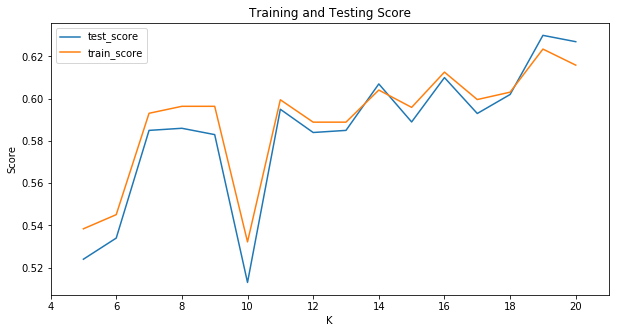

```
Max Test score is  0.63 with K =  19
Max Train score is  0.6235
```

```python
#Call the knn_func with max k is 20
best_test_score, best_k=knn_func(20,tbl_train,tbl_train_target,tbl_test,tbl_test_target)
```

```python
#Copy the dummy dataset in order to avoiding any false manipulation
tbl_dummies1 = np.array(tbl_dummies).copy()
tbl_target1 = np.array(tbl_target).copy()
```

```python
tbl_target1.shape
```

[output not shown]

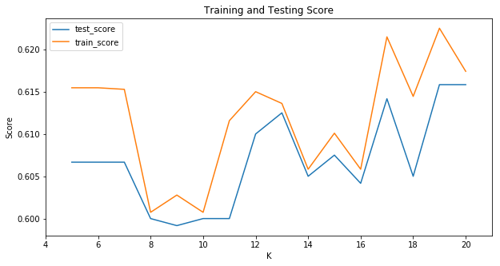

```
Max Test score is  0.615833333333 with K =  19
Max Train score is  0.6225
```

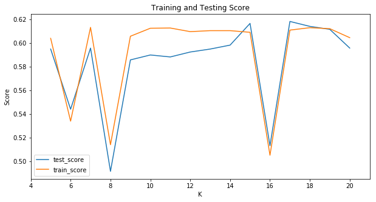

```
Max Test score is  0.618333333333 with K =  17
Max Train score is  0.613333333333
```

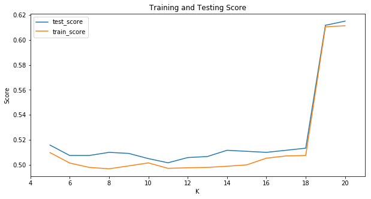

```
Max Test score is  0.615 with K =  20
Max Train score is  0.611296296296
```

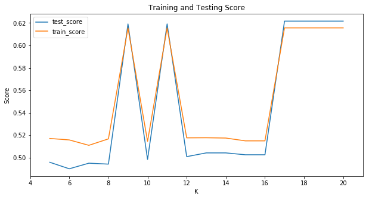

```
Max Test score is  0.621666666667 with K =  17
Max Train score is  0.615648148148
```

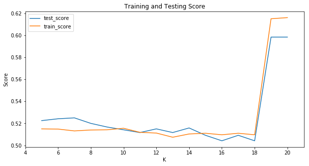

```
Max Test score is  0.598333333333 with K =  19
Max Train score is  0.616018518519
```

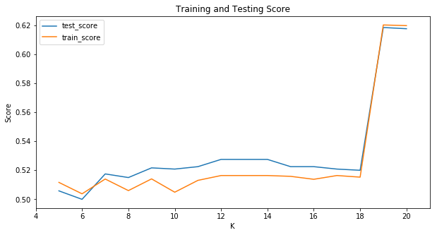

```
Max Test score is  0.618333333333 with K =  19
Max Train score is  0.620092592593
```

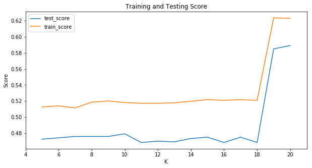

```
Max Test score is  0.589166666667 with K =  20
Max Train score is  0.623703703704
```

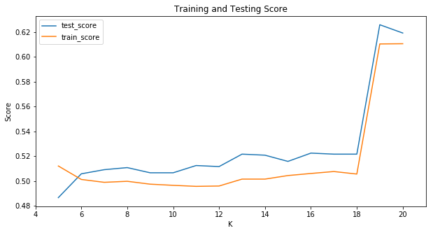

```
Max Test score is  0.625833333333 with K =  19
Max Train score is  0.610555555556
```

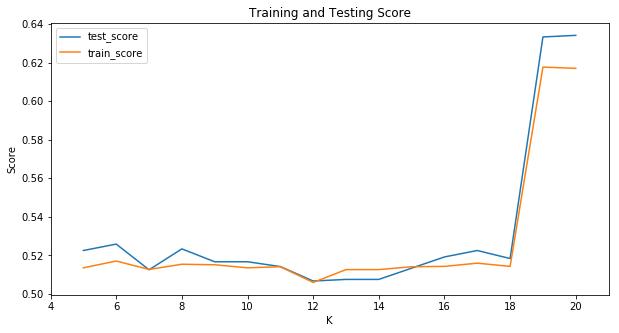

```
Max Test score is  0.634166666667 with K =  20
Max Train score is  0.617685185185
```

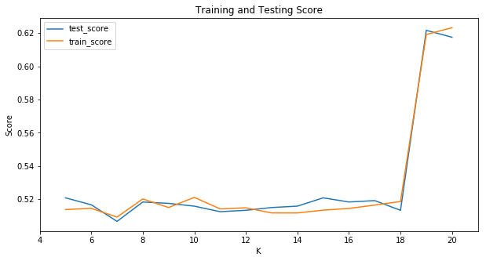

```
Max Test score is  0.621666666667 with K =  19
Max Train score is  0.623240740741
Accuacy  K
----------
0.634166666667 	 20
0.625833333333 	 19
0.621666666667 	 19
0.621666666667 	 17
0.618333333333 	 19
0.618333333333 	 17
0.615833333333 	 19
0.615 	 20
0.598333333333 	 19
0.589166666667 	 20
```

```python
from sklearn.cross_validation import KFold

best_test_score_lst=[]
best_k_lst=[]

#set the number of fold for cross validation
n = 10
kf = KFold(len(tbl_dummies1), n_folds=n) #
xval_err = 0
for train,test in kf:
    best_test_score, best_k=knn_func(20,tbl_dummies1[train],tbl_target1[train],tbl_dummies1[test],tbl_target1[test])
    best_test_score_lst.append(best_test_score)
    best_k_lst.append(best_k)
best_test_score_lst=np.array(best_test_score_lst)
best_k_lst=np.array(best_k_lst)


idx = np.argsort(best_test_score_lst)[::-1]
idx = np.array(idx)

print("Accuacy  K")
print("----------")
for i in idx:
    print(best_test_score_lst[i],"\t",best_k_lst[i])
```

#### The average accuracy reaches 61.6% and K=19 was ranked 5 time out of 10-fold cross validation. Based on the this result, I can propose that k=19 would be the best model in this kNN modelling process. Also, I think there is NO under-fitting or over-fitting for the above models.

### Navie Bayes (Gaussian) Classifier from sklearn

```python
#Set up Naive_bayes Gaussian classifier object
nbclf = naive_bayes.GaussianNB()
#Plug in the train dataset with target class
nbclf=nbclf.fit(tbl_train, tbl_train_target)
```

```python
#Get the score on the training and testing set
print('Train Score is',nbclf.score(tbl_train, tbl_train_target))
print('Test Score is',nbclf.score(tbl_test, tbl_test_target))
```

```
Train Score is 0.607118454307
Test Score is 0.606804748341
```

```python
print(tbl_dummies.shape)
print(tbl_target.shape)
```

```
(607366, 40)
(607366, 1)
```

```python
#10-fold Cross-Validation on the unsplited dataset
from sklearn import cross_validation
cv_scores = cross_validation.cross_val_score(nbclf, tbl_dummies,tbl_target[0], cv=10)
print('Overall Average accuracy: %f +/- %f'%(cv_scores.mean(),cv_scores.std()))
```

```
Overall Average accuracy: 0.600392 +/- 0.012393
```

#### The above shows that the best result of the Navie Bayes classifier is about 60%

### Decision Tree Classifier (Using the Default Parameters) from sklearn

```python
#Set up Decision Tree classifier
treeclf = tree.DecisionTreeClassifier(criterion='entropy')
#Plug in the train dataset with target class
treeclf = treeclf.fit(tbl_train, tbl_train_target)
```

```python
print('Traing set score is',treeclf.score(tbl_train, tbl_train_target))
print('Testing set score is',treeclf.score(tbl_test, tbl_test_target))
```

```
Traing set score is 0.623704444609
Testing set score is 0.622380097799
```

```python
#10-fold Cross-Validation on the unsplited dataset
from sklearn import cross_validation
cv_scores = cross_validation.cross_val_score(treeclf, tbl_dummies,tbl_target[0], cv=10)
print('Overall Average accuracy: %f +/- %f'%(cv_scores.mean(),cv_scores.std()))
```

```
Overall Average accuracy: 0.620150 +/- 0.024957
```

#### The above shows that the best result of the Decision Tree Classifer is about 62%

### Linear Discriminant Analysis (LDA) from sklearn

```python
from sklearn.discriminant_analysis import LinearDiscriminantAnalysis
ldclf = LinearDiscriminantAnalysis()
ldclf = ldclf.fit(tbl_train, tbl_train_target)
```

```python
print('Traing set score is',ldclf.score(tbl_train, tbl_train_target))
print('Testing set score is',ldclf.score(tbl_test, tbl_test_target))
```

```
Traing set score is 0.620658500243
Testing set score is 0.620857138153
```

```python
#10-fold Cross-Validation on the unsplited dataset
from sklearn import cross_validation
cv_scores = cross_validation.cross_val_score(ldclf, tbl_dummies,tbl_target[0], cv=10)
print('Overall Average accuracy: %f +/- %f'%(cv_scores.mean(),cv_scores.std()))
```

```
Overall Average accuracy: 0.619351 +/- 0.024136
```

### kMeans from sklearn

```python
#import Kmeans module from sklearn library
from sklearn.cluster import KMeans
```

```python
tbl_dummies = np.array(tbl_dummies)
print(tbl_dummies.shape)
print(type(tbl_dummies))
```

```
(607366, 40)
<class 'numpy.ndarray'>
```

```python
tbl_target = np.array(tbl_target)
print(tbl_target.shape)
print(type(tbl_target))
```

```
(607366, 1)
<class 'numpy.ndarray'>
```

```python
kmeans=KMeans(n_clusters=2,max_iter=500,verbose=0) #initialize clusters parameters
#Plug in the normalized data into the
kmeans.fit(tbl_dummies)
```

```
KMeans(algorithm='auto', copy_x=True, init='k-means++', max_iter=500,
    n_clusters=2, n_init=10, n_jobs=1, precompute_distances='auto',
    random_state=None, tol=0.0001, verbose=0)
```

```python
#Predict the dummies dataset
clusters=kmeans.predict(tbl_dummies)
print(len(clusters))
print(tbl_target.shape[0])
```

```
607366
607366
```

```python
#Check the accuracy of the Predicted Class by comparing with the target value from original dataset
if len(clusters)==tbl_target.shape[0]:
    acc_count=0
    percent_acc=-1
    for i in range(len(clusters)):
        if clusters[i]==tbl_target[i]:
            acc_count+=1
    percent_acc=acc_count/len(tbl_target)
print("Accuaacy of K-Mean is ",percent_acc*100,"%")
```

```
Accuaacy of K-Mean is  59.827352864664796 %
```

#### The above shows that the best result of the KMeans Classifier is about 59.8%

### KNN Classifier (Self coded)

```python
tbl_dummies=pd.DataFrame(np.array(tbl_dummies))
tbl_target=pd.DataFrame(np.array(tbl_target))
#Split the train set, test set, train class, test class
from sklearn.cross_validation import train_test_split
tbl_train,tbl_test,tbl_train_target,tbl_test_target=train_test_split(tbl_dummies
                                                                     ,tbl_target
                                                                     ,test_size=0.2
                                                                     ,random_state=68)
```

```python
import math
from collections import Counter
# x = the instance to be classified
# D = training data matrix
# C = Class of neighbor of training data
# K is the number of neigbor
# measure is the method is used to calculation the similarity (0=Euclidean Dist, 1=Cosine)

def knn_classifier(x,D,cc,K,measure):
    if measure == 0: #Use Euclidean Distance Function
        D=np.array(D)
        dists = np.array(np.sqrt(((D - x)**2).sum(axis=1)))

        idx = np.argsort(dists)
        neighbor_class = cc.iloc[idx[:K]]
        predict_class=Counter(neighbor_class[0]).most_common(1)

        return dists[idx[:K]],idx[:K],neighbor_class,predict_class[0][0]

    elif measure ==1: #Use Cosine Distance Function
        D=np.array(D)
        dot_pro = np.dot(D,x)
        x_norm = np.linalg.norm(x)
        D_norm = np.sqrt((D*D).sum(axis=1))#np.array([np.linalg.norm(D.iloc[i]) for i in range(len(D))])
        sims=dot_pro / (x_norm * D_norm)
        dists=np.array(1-sims)

        idx=np.argsort(dists)
        neighbor_class=cc.iloc[idx[:K]]
        predict_class=Counter(neighbor_class[0]).most_common(1)

        return dists[idx[:K]],idx[:K],neighbor_class,predict_class[0][0]

    else:
        #Return nothing if Input of Measure is NOT 0 or 1.
        print("Measure must be 0 or 1")
        return
```

```python
def accuracy(train,train_class,test,test_class,K,measure):
    pre_class_array=np.array([])
    for i in range(len(test)):
        instance = np.array(test.iloc[i])
        dists,idx,neighbor_class,predict_class=knn_classifier(instance,train,train_class,K,measure)
        pre_class_array=np.append(pre_class_array,predict_class)

    if len(pre_class_array)==test_class.shape[0]:
        acc_count=0
        for i in range(len(pre_class_array)):
            if pre_class_array[i]==test_class.iloc[i][0]:
                acc_count+=1
        percent_acc=acc_count/len(test_class)

    return pre_class_array,percent_acc
```

```python
import matplotlib.pyplot as plt
%matplotlib inline

def knn_accuracy(train ,train_target ,test,test_target,k_min,k_max,measure):

    k_max=(K_max+1)
    pre_class_array_lst=[]
    percent_acc_lst=[]
    K_lst=[]

    for num in range(k_min,k_max):
        pre_class_array,percent_acc=accuracy(train,train_target,test,test_target,num,measure)
        pre_class_array_lst.append(pre_class_array)
        percent_acc_lst.append(percent_acc)
        K_lst.append(num)

    accuracy_df=pd.DataFrame({'Accuracy':percent_acc_lst,"K":K_lst})
    accuracy_df.plot(x='K',figsize=(10,5))
    plt.title('KNN Accuracy')
    plt.xlabel('K Values')
    plt.ylabel('Accuracy')
    plt.xlim([k_min-1,k_max])
    plt.show()

    best_accuaracy=0.0
    best_k=-1
    best_class=np.array([])
    best_accuracy = max(percent_acc_lst)
    best_k = K_lst[percent_acc_lst.index(max(percent_acc_lst))]
    best_class = pre_class_array_lst[percent_acc_lst.index(max(percent_acc_lst))]

    #print(percent_acc_lst)
    print ('Max Accuracy score is ',best_accuracy,'with K =',best_k)

    return best_accuracy,best_k, best_class
```

```python
#Turn the table to DataFrame before splitting into Train and Test dataset
tbl_dummies=pd.DataFrame(np.array(tbl_dummies))
tbl_target=pd.DataFrame(np.array(tbl_target))

#Split the train set, test set, train class, test class
from sklearn.cross_validation import train_test_split
tbl_train,tbl_test,tbl_train_target,tbl_test_target=train_test_split(tbl_dummies
                                                                     ,tbl_target
                                                                     ,test_size=0.2
                                                                     ,random_state=68)
```

```python
#Initialize the variables entries before call the knn_accuracy function
D=tbl_train
c=tbl_train_target
K_min=5
K_max=20
measure = 1

best_k=-1
best_class=np.array([])
```

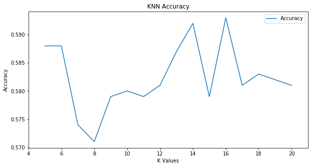

```
[0.588, 0.588, 0.574, 0.571, 0.579, 0.58, 0.579, 0.581, 0.587, 0.592, 0.579, 0.593, 0.581, 0.583, 0.582, 0.581]
Max Accuracy score is  0.593 with K = 16
```

```python
#Call the knn_accuracy function to find the best k value with Eudlidean Distance function (Measure=0)
best_accuracy,best_k, best_class = knn_accuracy(D,c,tbl_test,tbl_test_target,K_min,K_max,0)
```

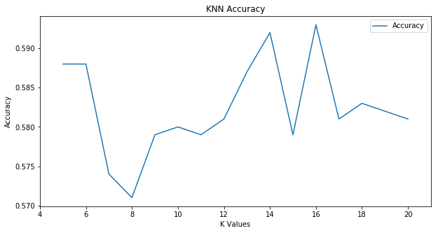

```
[0.588, 0.588, 0.574, 0.571, 0.579, 0.58, 0.579, 0.581, 0.587, 0.592, 0.579, 0.593, 0.581, 0.583, 0.582, 0.581]
Max Accuracy score is  0.593 with K = 16
```

```python
#Call the knn_accuracy function to find the best k value with Cosine Distance function (Measure=1)
best_accuracy,best_k, best_class = knn_accuracy(D,c,tbl_test,tbl_test_target,K_min,K_max,1)
```

#### As we observe the above kNN classifier plots, the results of using Euclidean and Cosine Distance is identical. In order to re-verify the result, 10-fold cross validation will be performed.

```python
print(type(tbl_dummies))
print(type(tbl_target))
print(tbl_dummies.shape)
print(tbl_target.shape)
```

[output not shown]

```python
tbl_dummies2 = tbl_dummies.copy()
tbl_target2 = tbl_target.copy()
```